# RRRR Ch.10: Showing Results with Figures

Andy Kaempf

September 5, 2016

# Set-up: prepare R environment

Load necessary packages

````
```{r}
library(knitr);     library(rmarkdown);
library(devtools);  library(repmis);
library(tidyr);     library(dplyr);
library(WDI);       library(ggplot2);
library(googleVis); library(RJSONIO);
library(Hmisc);     library(gridExtra);
```
````

Set working directory and global chunk options

````
```{r label=setup}
setwd('H:/Reproducible Research/Reproducibility study group/Andy files')
knitr::opts_chunk$set(message=FALSE, warning=FALSE, fig.path='Ch10_figures/');
```
````

# Outline of “Slidy” HTML presentation

- Benefits of including dynamic figures
- Non-knitted graphics in presentation documents
  - **R Markdown** documents (.Rmd)
  - **R LaTeX** documents (.Rnw)
- `knitr` code chunk options for figures
- Figures from default R graphics in presentation docs
- Figures from `ggplot2` graphics in presentation docs
- Interactive images from `googleVis` package

# Advantages of including dynamic figures

1. In R Markdown or LaTeX files, figures are not copy-and-pasted like in MS Word. Instead, figures are included by **linking** to the image file (.png, .pdf, .jpeg)
   - if an image changes, the presentation document will reflect this change the next time the markup document is compiled. No recopying and repasting is necessary.
2. Dynamic figures are *sized* and *aligned* with markup code rather than by pointing and clicking. This takes more time up front but saves time when making updates, allows for consistent formatting for all included figures, and is reproducible
3. Because the images are *not actually loaded* in markup documents, this method of linking avoids the lag time often experienced while editing a Word doc that contains many images

# Non-knitted graphics in R Markdown (slide 1)

A “non-knitted” graphic is one that already exists outside the knittable document and is not created by R code in a `knitr` code chunk.

Use the following code in a .Rmd file to include a non-knitted image

```
  ![text](file path)
```

- [text] indicates the HTML **alt** attribute and should be a short description of the image that will appear if the image fails to load in the web browser
- (file path) is the image’s file path/name or URL
- `![]()` is similar to the `[]()` syntax used to include a hyperlink

# Non-knitted graphics in R Markdown (slide 2)

Markdown does not allow you to resize or position your image so you must use the HTML image (‘img’) tag and assign the image’s file path/name to the **src** attribute.

In .Rmd files, include images (like the below image of butterflies) that can be sized and aligned using HTML markup like so:

```
  <img src="four_butterflies.jpg"
   alt="Butterflies"
   width="500px" height="375px"></img>
```

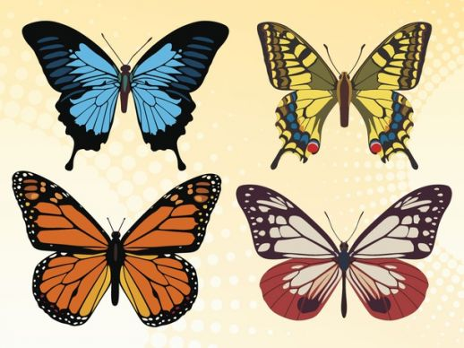

# Non-knitted graphics in R Markdown (slide 3)

The HTML **src** attribute can also accept a URL.

This picture of lions (centered with ‘center’ tag) was included with the code:

```
  <center><img src="http://thumbs.media.smithsonianmag.com
   //filer/two-male-lions-Kenya-631.jpg__800x600_q85_crop.jpg"
   alt="Lions"
   width="560px" height="420px"></img></center>
```

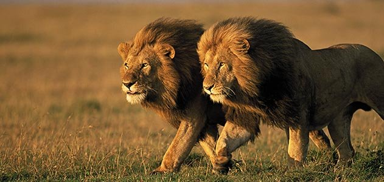

# Non-knitted graphics in R LaTeX (slide 1)

In .Rnw files, link to images using the **includegraphics** command:

```
  \includegraphics[options]{file path}
```

A picture of four butterflies (Meyer 2006) is included in a LaTeX document with the code:

```
  \begin{figure}[h]
    \caption{Caption goes here}
    \label{lab_name}
    \includegraphics[width=3in,keepaspectratio=true]{Meyer_2006.png}
    {\small{Source: \cite{meyer2006repeating}}}
  \end{figure}
```

By linking to this image from within the *figure* float environment, the image can be “floated” away from the document text at a specified location and given a caption (`\caption` command)

LaTeX automatically numbers figures that are **cross-referenced** with the `\label` command. Use `\ref` command where you want the figure’s number to be printed and `\pageref` for the figure’s page number

POSITION_SPEC arguments go inside brackets after `\begin{figure}`  
– ‘h’ places the table where it is written in the text (ie, here), ‘t’ places it at the top of the page, and ‘b’ at the bottom of the page

# Non-knitted graphics in R LaTeX (slide 2)

Notes about including pre-existing images with LaTeX markup

- to access all **includegraphics** features, load the `graphicx` package in the LaTeX document’s preamble (ie, top portion of the file above *document* environment)
  - use LaTeX command **usepackage** to load a package in LaTeX
- `width=3in` sets the image width at 3 inches. Other image size or alignment options are: ‘scale’, ‘height’, ‘angle’, and ‘keepaspectratio’
- `scale=0.8` makes the image 80 percent of its actual size and `width=0.8\textwidth` sets the image width to 80 percent of the document’s text width via the LaTeX command **textwidth**
  - if **textwidth** is included in a code chunk, two backslashes must precede it: the first one as the R escape character and the second one as the beginning of the LaTeX command

# [Code chunk figure options](http://yihui.name/knitr/options/#chunk_options)

- fig.path – specify a file path to a directory where `knitr` will store figure files
- fig.align – alignment of figure in presentation doc (‘left’, ‘center’, ‘right’)
- fig.height & fig.width – height/width of the saved plot (default is 7 in)
- dev or fig.ext – ‘graphical device’ or ‘figure extension’ to save image as
  - possible values: ‘png’, ‘pdf’, ‘bmp’, ‘jpeg’, ‘gif’, ‘tiff’, ‘eps’
- fig.cap – set figure’s caption/title
- fig.lb – set figure’s label for cross-references (LaTeX)
- out.height & out.width – height/width to scale the figure in the presentation doc

**R Markdown** files: ‘out.height’ and ‘out.width’ take arguments with units of pixels (px)

**R LaTeX** files: ‘out.height’ and ‘out.width’ take arguments with units of inches (in), centimeters (cm), or scaled as a proportion of a page element

# R default graphics – Example #1 (slide 1)

**Goal**: Create a *scatterplot* of cars’ speeds and stopping distances

**Data Source**: Preloaded `cars` dataset. Type `?cars` into the R console to learn about this dataset.

**Steps** to produce the *scatterplot*:

1. Inspect the data
2. use **plot()** function to create the plot

Extra: **plot()** is a generic function, meaning it invokes **UseMethod()** to determine the class of its first argument and then search for a plot function specific to this class. If no class-specific function is found, **plot.default()** is called.

Other R default graphic commands are **hist()**, **boxplot()**, **pie()**, **stars()**

# R default graphics – Example #1 (slide 2)

Step #1: inspect the data

```r
# look at variables in cars data.frame
str(cars)
## 'data.frame':    50 obs. of  2 variables:
##  $ speed: num  4 4 7 7 8 9 10 10 10 11 ...
##  $ dist : num  2 10 4 22 16 10 18 26 34 17 ...
```

**str()** gives the structure of an object and lists its components – which are two numeric variables: *speed* and *dist*

Step #2: create the *scatterplot*

````
```{r cars, fig.align='center', fig.height=6, fig.width=6, dev='jpeg'}
plot(x = cars$speed, y=cars$dist,
     main = "Scatterplot:  default R graphics",
     xlab = "Speed (mph)", ylab = "Stopping Distance (feet)",
     cex.lab = 1.25, cex.main = 1.5, pch=8)
abline(lsfit(cars$speed,cars$dist), lwd=2.5, col="red")
lines(lowess(cars$speed,cars$dist), lwd=2.5, col="blue")
legend(x=5, y=115, c("linear regression","loess smoother"),
       lwd=2.5, col=c("red","blue"))
```
````

Note that a **JPEG** of the scatterplot is created by `knitr` (default is PNG for .Rmd)

# R default graphics – Example #1 (slide 3)

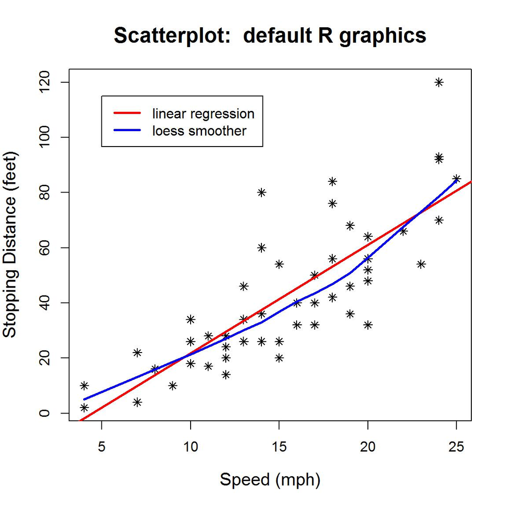

A simpler version of this *scatterplot* can be created by sourcing a code file hosted on GitHub

```
source_url("https://raw.githubusercontent.com/christophergandrud
            /Rep-Res-Examples/master/Graphs/SimpleScatter.R")
```

# R default graphics – Example #2 (slide 1)

**Goal**: Create *scatterplot matrix* of World Bank variables

**Data source**: World Bank’s Development Indicators database (The World Bank Group 2016), accessed by either:

- downloading data directly via `WDI` package that utilizes the World Bank [website](http://data.worldbank.org/data-catalog/world-development-indicators) API.
  - pass in text argument ‘fertilizer consumption’ to **WDIsearch()** function and then select an indicator of an available World Bank variable pertaining to the text argument by using the **WDI()** function (see RRRR p.124)
- downloading the data (.csv) from the author’s GitHub page using `repmis` package’s **source_data()** function

Other R packages that enable direct downloads of web data by utilizing API’s are found [here](http://stats.stackexchange.com/questions/12670/data-apis-feeds-available-as-packages-in-r). Examples include `twitteR` (for tweets and trending topics), `quantmod` (for Google and Yahoo finance data), and `ZillowR` (for real estate and mortgage data)

**Steps** to produce *scatterplot matrix*:  
1. Load data and examine variable names  
2. Subset the data (only include 2003 obs.) and remove ID variables  
3. use **pairs()** function to create the figure

# R default graphics – Example #2 (slide 2)

Step #1: load data from [GitHub](http://bit.ly/V0ldsf), list variable names, and make sure the three variables being plotted are quantitative

```
MainData <- source_data("https://raw.githubusercontent.com/christophergandrud
                         /Rep-Res-Examples/master/DataGather_Merge/MainData.csv")
```

```r
# make sure source_data() loads a data.frame object
class(MainData)
## [1] "data.frame"

names(MainData)
## [1] "V1"                    "iso2c"                 "year"
## [4] "country"               "reg_4state"            "disproportionality"
## [7] "FertilizerConsumption"

# shorten variable names with rename()
MainData2 <- dplyr::rename(MainData, Fert = FertilizerConsumption, disprop = disproportionality)

# sapply() applies a function to each element of the 1st arg and returns a vector
# sapply() is a wrapper for lapply(), which returns a list
sapply(MainData2[,5:7], class)
## reg_4state    disprop       Fert
##  "integer"  "numeric"  "numeric"
```

# R default graphics – Example #2 (slide 3)

Step #2: subset the data and assess the quantitative variables of interest

```r
# these two commands do the same thing (only run 1 of them)
SubData <- MainData2 %>% dplyr::filter(year == 2003) %>% dplyr::select(reg_4state, disprop, Fert)
SubData2 <- subset(MainData2[, 5:7], MainData2$year == 2003)
```

```r
# compute frequency counts of discrete var's levels
table(SubData$reg_4state)
##
##  1  2  3  4
## 16 15 19 33

# compute summary stats for continuous vars.
lapply(SubData[,c("disprop", "Fert")], summary, digits=3)
## $disprop
##    Min. 1st Qu.  Median    Mean 3rd Qu.    Max.    NA's
##    1.05    2.48    3.98    5.73    7.74   20.80      69
##
## $Fert
##    Min. 1st Qu.  Median    Mean 3rd Qu.    Max.    NA's
##     1.6    78.9   136.0   367.0   293.0 11600.0       2

# remove rows with very large fertilizer values
No_tail <- subset(SubData, Fert < 1000)
```

Extra: use **describe()** function from `Hmisc` package to provide extra summary info such as number of unique values and the lowest 5 and highest 5 values

# R default graphics – Example #2 (slide 4)

Step #3: create the *scatterplot matrix* with this code chunk:

````
```{r WB_plot, fig.cap="Caption is placed here", fig.align='center'}
pairs(x = No_tail, main="WB development indicators", lower.panel=NULL)
```
````

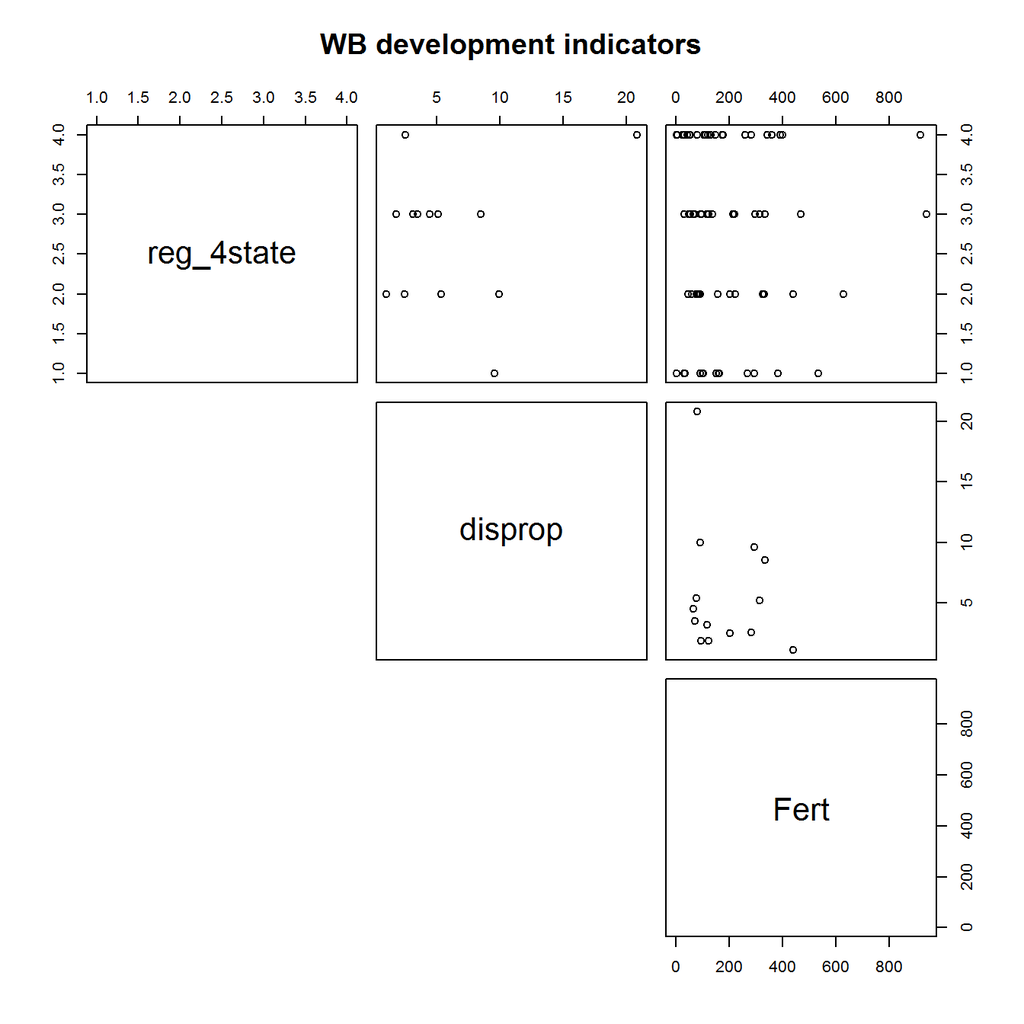

Caption is placed here

# References for R default graphics

- [Quick-R webpage on Graphs](http://www.statmethods.net/advgraphs/)
- [R Graphics Cookbook: Practical Recipes for Visualizing Data](http://ase.tufts.edu/bugs/guide/assets/R%20Graphics%20Cookbook.pdf) (Chang, 2012)
- [R Graphics](https://www.stat.auckland.ac.nz/~paul/RGraphics/rgraphics.html) book (Murrell, 2011)

# Intro to knitting ggplot2 graphics (slide 1)

- `ggplot2` is an R package for creating publication-quality figures
- ‘gg’ = *grammer of graphics*, referring to a formal, structured approach to building figures by adding component **layers**. Layers can be the coordinate system, points, lines, etc.
- the main layers are called `geoms` (geometric objects), which are the visual representations of data points
- `geom` examples (listed as R function names):
  - geom_point() – scatterplots
  - geom_bar() – bar charts
  - geom_boxplot() – box–and–whisker plots
  - geom_smooth() – smooth line fit to data with ‘lowess’ as default
  - geom_text() – textual annotations
- layers have **aesthetics** (visual properties) added to figures with ‘aes()’ argument. Examples of aesthetics are the variables assigned to axes, label sizes, colors, and shapes.

# Intro to knitting ggplot2 graphics (slide 2)

According to the book ‘ggplot2: Elegant Graphics for Data Analysis, 2nd ed.’ (see Wickham 2016), all plots created by `ggplot2` have three key components:

1. The **data**
2. The **aesthetic mapping** of variables to visual features
3. **Layers** that describe how to render the observations. Most layers are created with a ‘geom’ function

An example of these 3 components using the `ggplot2` dataset ‘mpg’:

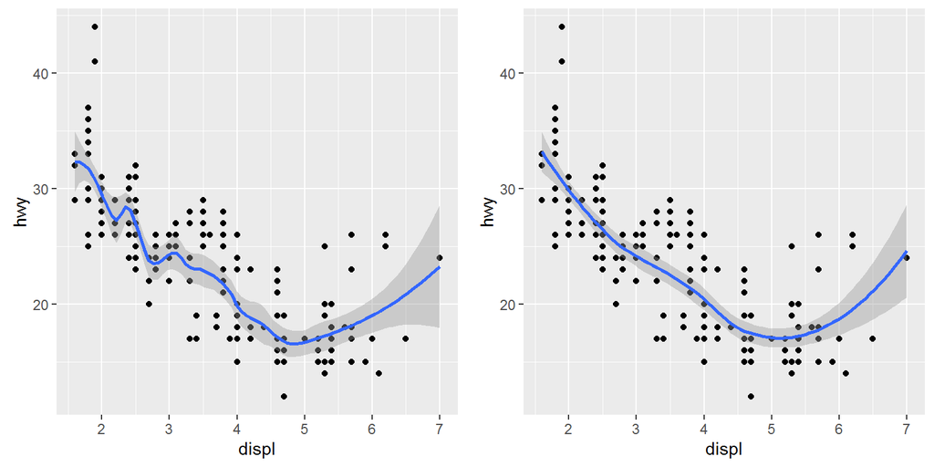

```r
plot1 <- ggplot(data=mpg, aes(x=displ, y=hwy)) + geom_point() + geom_smooth(span=0.3)
plot2 <- ggplot(data=mpg, aes(x=displ, y=hwy)) + geom_point() + geom_smooth(span=0.7)
gridExtra::grid.arrange(plot1, plot2, ncol=2)
```

- References:
  - [ggplot2 reference manual](https://cran.r-project.org/web/packages/ggplot2/ggplot2.pdf)
  - [official ggplot2 documentation](http://docs.ggplot2.org/current/)
  - [Vanderbilt University ggplot2 workshop](http://ggplot2.org/resources/2007-vanderbilt.pdf)
  - [Rstudio’s ggplot2 cheatsheet](https://www.rstudio.com/resources/cheatsheets/)

# ggplot2 – Example #1 (slide 1)

**Goal**: Create *line plot* showing change over time of actual and forecasted inflation

**Data source**: stored on the author’s [GitHub page](https://raw.githubusercontent.com/christophergandrud/Rep-Res-Examples/master/Graphs/InflationData.csv)

Download data from a GitHub page using the `repmis` package’s **source_data()** command and passing the data file URL as the lone argument

**Steps** to produce the *time series plot*:

1. Load data and examine data structure
2. Reshape data with `tidyr` to prepare for using `ggplot2`
3. Use **ggplot()** function to create the line plot

# ggplot2 – Example #1 (slide 2)

Step #1: Download the data

````
```{r eval=TRUE, include=TRUE}
InflationData <- repmis::source_data("https://raw.githubusercontent.com
/christophergandrud/Rep-Res-Examples/master/Graphs/InflationData.csv");
```
````

Determine variable names and inspect the first 5 observations

```r
dim(InflationData)
## [1] 152   3
names(InflationData)
## [1] "Quarter"            "ActualInflation"    "EstimatedInflation"
head(InflationData,n=5)
##   Quarter ActualInflation EstimatedInflation
## 1  1969.1              NA            4.55342
## 2  1969.2             3.5            4.80281
## 3  1969.3             3.5            5.28242
## 4  1969.4             3.3            5.14525
## 5  1970.1             3.7            5.54280
```

There are **3 variables** in this dataset:  
1. *Quarter*: the year and fiscal quarter  
2. *ActualInflation*: the actual U.S. inflation rate for the given quarter  
3. *EstimatedInflation*: Federal Reserve’s inflation forecast made two quarters prior

# ggplot2 – Example #1 (slide 3)

To plot a separate line for each inflation measurement, we need to restructure the data so that *ActualInflation* and *EstimatedInflation* become the values of a new variable (*key*) and the measures themselves are stored in a separate variable (*value*).

Step #2: Reshape data with `tidyr` package:

- use **gather()** to convert to long-format and **spread()** to convert to wide-format
- last argument of **gather()** indicates column positions of the variables to ‘gather’

```r
# reshape data from wide to long format with `gather` command
GatheredInflation <- tidyr::gather(data=InflationData, key=key, value=value, 2:3)

# notice there are now twice as many obs. (hence, long format)
dim(GatheredInflation)
## [1] 304   3

# inspect the first 5 observations of the long-format dataset
head(GatheredInflation,n=5)
##   Quarter             key value
## 1  1969.1 ActualInflation    NA
## 2  1969.2 ActualInflation   3.5
## 3  1969.3 ActualInflation   3.5
## 4  1969.4 ActualInflation   3.3
## 5  1970.1 ActualInflation   3.7
```

# ggplot2 – Example #1 (slide 4)

Step #3: Create the multi-line *time series plot* using **ggplot()**

````
```{r label=time_plot, fig.align='center'}
LinePlot <- ggplot2::ggplot(data = GatheredInflation,
        aes(x = Quarter, y = value, color = key, linetype = key)) +
        geom_line() +
        scale_color_discrete(name="", labels=c("Actual","Estimated")) +
        scale_linetype(name="", labels=c("Actual","Estimated")) +
        xlab("\n Quarter") + ylab("Inflation\n") + theme_bw(base_size = 15)
print(LinePlot)
```
````

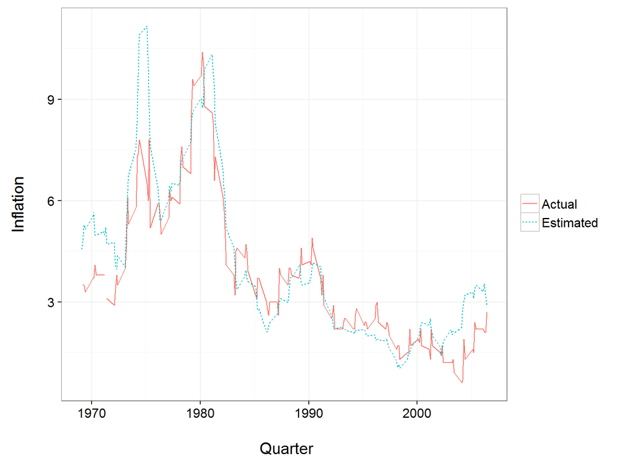

# ggplot2 – Example #1 (slide 5)

Explanation of `ggplot2` functions used:

- **ggplot()** – initializes plot by identifying the dataset and setting plot aesthetics
- **geom_line()** – connects observations in order of the x-axis variable
- **scale_color_discrete()** – hides legend title (with ‘name’) but defines legend labels associated with line colors
- **scale_linetype()** – hides legend title but defines legend labels associated with line types
- **xlab()** and **ylab()** – provide axis labels
- **theme_bw()** – sets a theme with a white background; argument ‘base_size’ controls the plot’s font size

You can reproduce this analysis by sourcing the R code file from GitHub at: http://bit.ly/VEvGJG. To run the entire analysis just shown, include the following R code in a chunk:

```
    devtools::source_url("http://bit.ly/VEvGJG")
```

# ggplot2 – Example #2 (slide 1)

**Goal**: Create a *caterpillar plot* showing estimates of a regression model’s parameters

**Data source**: `swiss` dataset preloaded with R. This dataset provides fertility and socioeconomic indicator data for 47 Swiss provinces from 1888.

**Steps** to produce the *caterpillar plot*:

1. Inspect the data
2. Fit the linear regression model (see ‘Note’ below)
3. Extract and reformat model output to prepare for plotting
4. Use **ggplot()** function to create the plot

Note: A frequentist rather than a Bayesian normal linear regression model (like what is shown in the book) is fit here because the `Zelig` package has been modified and the author’s code no longer works (according to the book’s [Errata page](http://christophergandrud.github.io/RepResR-RStudio/errata.htm).)

# ggplot2 – Example #2 (slide 2)

Step #1 – inspect the data

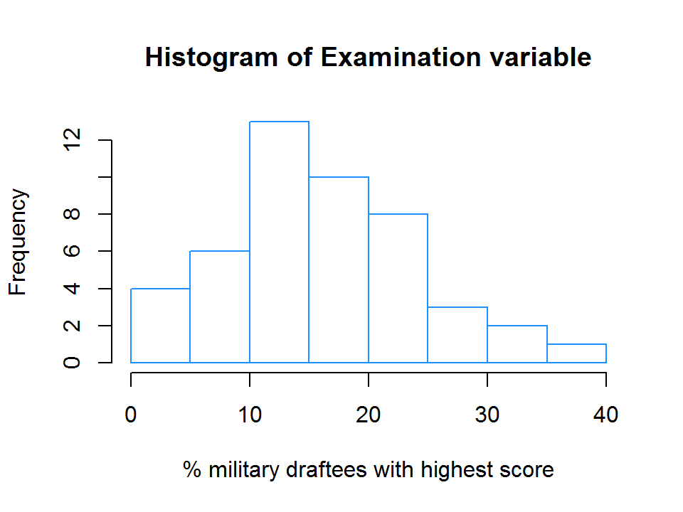

```r
# determine number of observations and variables in data.frame
dim(swiss)
## [1] 47  6

# list variable names
names(swiss)
## [1] "Fertility"        "Agriculture"      "Examination"
## [4] "Education"        "Catholic"         "Infant.Mortality"

# show distribution of outcome measure
hist(x=swiss$Examination, xlab="% military draftees with highest score",
    main = "Histogram of Examination variable", border="dodgerblue")
```

# ggplot2 – Example #2 (slide 3)

Steps #2 and #3 – fit the model with **lm()** and reformat output

Model the percentage of draftees receiving the highest army exam score (**Examination**) as a function of educational level (**Education**), male involvement in agriculture (**Agriculture**), proportion of catholics (**Catholic**), and infant mortality rate (**Infant.Mortality**). Each observation is a separate Swiss province.

```r
# fit the model
LinearModel <- lm(Examination ~ Education + Agriculture +
                  Catholic + Infant.Mortality, data = swiss)

# create the summary object and save the coefficient estimates
Model_coeff_DF <- data.frame(summary(LinearModel)$coefficients)

# make row.names attribute into a new column/variable
Model_coeff_DF$Coeff <- row.names(Model_coeff_DF)

# extract the confidence limits for the coefficients using confint()
CI_DF <- data.frame(confint(LinearModel))

# make row.names attribute a new column of CI data.frame
CI_DF$Coeff <- row.names(CI_DF)

# merge the two data frames to combine the point and interval estimates
merged_DF <- merge(Model_coeff_DF,CI_DF)

# remove intercept so coefficients are plotted on a more interpretable scale
final_DF <- subset(merged_DF, Coeff != "(Intercept)")
```

# ggplot2 – Example #2 (slide 4)

Step #4: create the *caterpillar plot*

````
```{r label=caterpillar, eval=TRUE}
CatPlot <- ggplot(data = final_DF, aes(x = reorder(Coeff, X2.5..),
           y = Estimate, ymin = X2.5.., ymax = X97.5..)) +
           geom_pointrange(size = 1.4) +
           geom_hline(aes(yintercept = 0), linetype = "dotted") +
           ggtitle("Caterpillar plot of regression estimates\n")
           xlab("Variable\n") + ylab("\nCoefficient Estimate") +
           coord_flip() + theme_bw(base_size = 20)
print(CatPlot)
```
````

New `ggplot2` commands:

- **geom_pointrange()** – geom that is a vertical line with a point in the middle
  - **reorder()** function reorders Coefficient names based on lower conf. limit values
- **geom_hline()** – geom that adds a horizontal line to a plot
  - **aes()** option should be ‘yintercept’ rather than ‘intercept’ like in the book
- **ggtitle()** – adds a plot title
- **coord_flip()** – flips/exchanges the coordinate axes

# ggplot2 – Example #2 (slide 5)

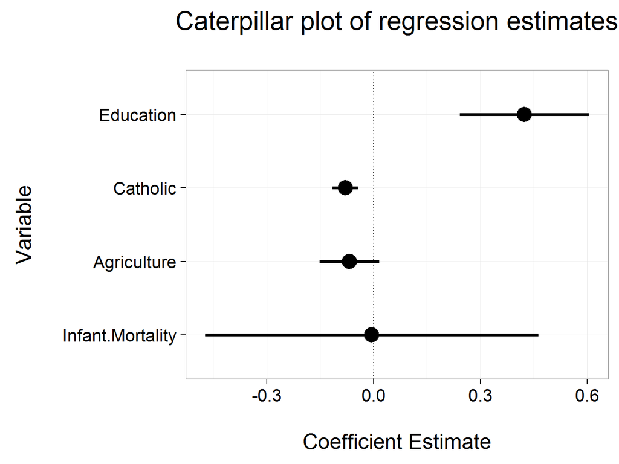

# ggplot2 – Example #3 (slide 1)

**Goal**: Create a boxplot inside a violin plot showing blood pressure distribution by gender

**Data source:** Online via Univ. of Washington professor Ken Rice’s [webpage](http://faculty.washington.edu/kenrice/heartgraphs/nhaneslarge.csv) and graphically analyzed in a paper (Rice and Lumley 2015)

R code modified from the OHSU Jamboree on Data Visualization (June 2016)

**Steps** to produce the *violin plot*:

1. Load the data
2. Examine the variables
3. Use **ggplot()** function to create the figure

# ggplot2 – Example #3 (slide 2)

Step #1: Download the data in 2 ways:

1. using **read_csv()** from `readr` package

   ```r
   heart <- read_csv("http://faculty.washington.edu/kenrice
                      /heartgraphs/nhaneslarge.csv", na=".")
   ```

2. using **source_data()** from `repmis` package

   ```r
   heart <- source_data("http://faculty.washington.edu/kenrice
                         /heartgraphs/nhaneslarge.csv")
   ```

Step #2: Examine var. names and summary stats for outcome measure (by sex)

```r
names(heart)
##  [1] "BPXSAR"    "BPXDAR"    "BPXDI1"    "BPXDI2"    "race_ethc"
##  [6] "gender"    "DR1TFOLA"  "RIAGENDR"  "BMXBMI"    "RIDAGEYR"

summary(heart[heart$gender == "Female",]$BPXSAR)
##    Min. 1st Qu.  Median    Mean 3rd Qu.    Max.
##    82.0   104.0   114.7   118.0   126.0   216.0

summary(heart[heart$gender == "Male",]$BPXSAR)
##    Min. 1st Qu.  Median    Mean 3rd Qu.    Max.
##    85.0   111.0   120.8   121.8   131.0   191.3
```

# ggplot2 – Example #3 (slide 3)

Step #3: Create the *violin plot* overlaid with a boxplot

````
```{r label=violin, fig.align='center'}
ggplot(heart, aes(x = gender, y = BPXSAR)) +
geom_violin(alpha = 0.5, size = 0.8) +
geom_boxplot(width = 0.2, size = 0.8, fill="cyan", outlier.colour=NA) +
stat_summary(fun.y=median, geom="point", fill="white", shape=21, size=4) +
stat_summary(fun.y=mean, geom="point", fill="red", shape=21, size=4) +
labs(title="SBP distribution by sex (NHANES)", x="Systolic BP (mmHg)", y="")
```
````

New `ggplot2` commands:

- **geom_violin()** – creates a violin plot, which is a mirrored KDE of a pdf
  - ‘alpha’ controls the transparency, ‘size’ controls the line thickness
- **geom_boxplot()** – creates a box-and-whisker plot that is sized and colored
  - boxplot outliers are hidden by setting their color to NA
- **stat_summary()** – summarizes y-values at a unique x-value (‘gender’ level)
  - places a white dot at the median SBP and a red dot at the mean SBP
- **labs()** – change axis labels and add title